# EEMB 146 Final Report: Example with Palmer Penguin Data (change this to your own title- puns encouraged!)

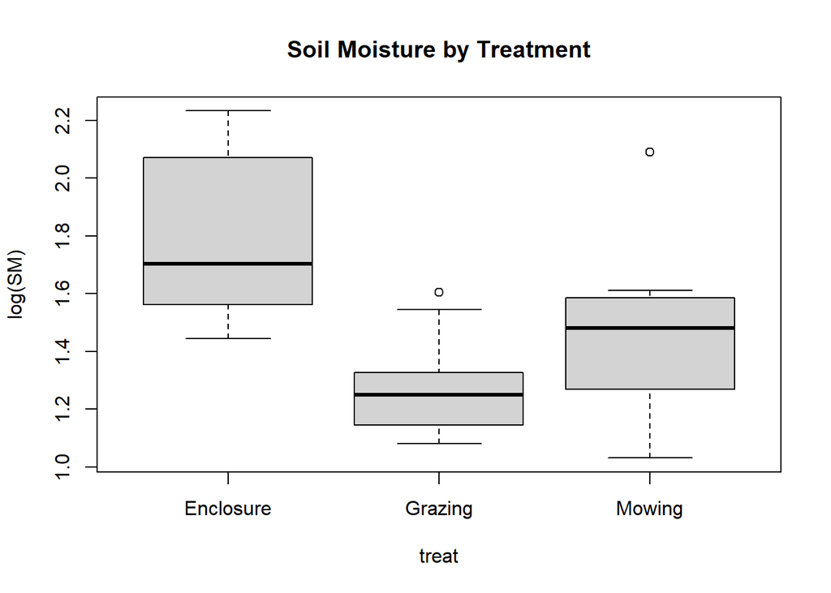

```r
boxplot(SM_log ~ treat, data = clean_data, main = "Soil Moisture by Treatment", ylab = "log(SM)")
```

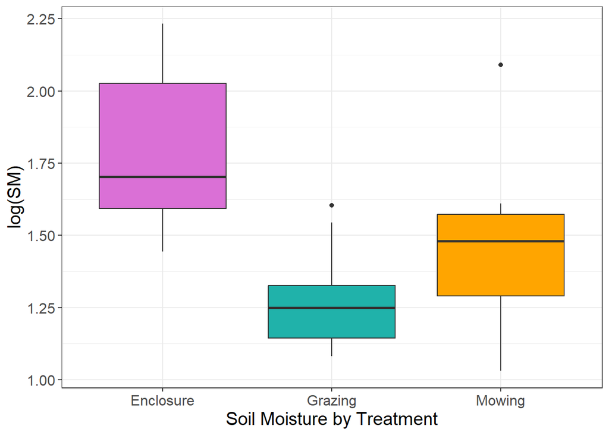

```r
ggplot(clean_data, aes(x=treat, y=SM_log, fill=treat, fill=treat))+ #base plot
  geom_boxplot(show.legend=F)+ #do a boxplot, but hide legend cause its just colors
  scale_fill_manual(values=c("orchid", "lightseagreen", "orange"))+ #set line colors
  ylab("log(SM)")+
  xlab("Soil Moisture by Treatment")+
  theme_bw()+ #cute theme
  theme(text = element_text(size=15)) # Larger font
```

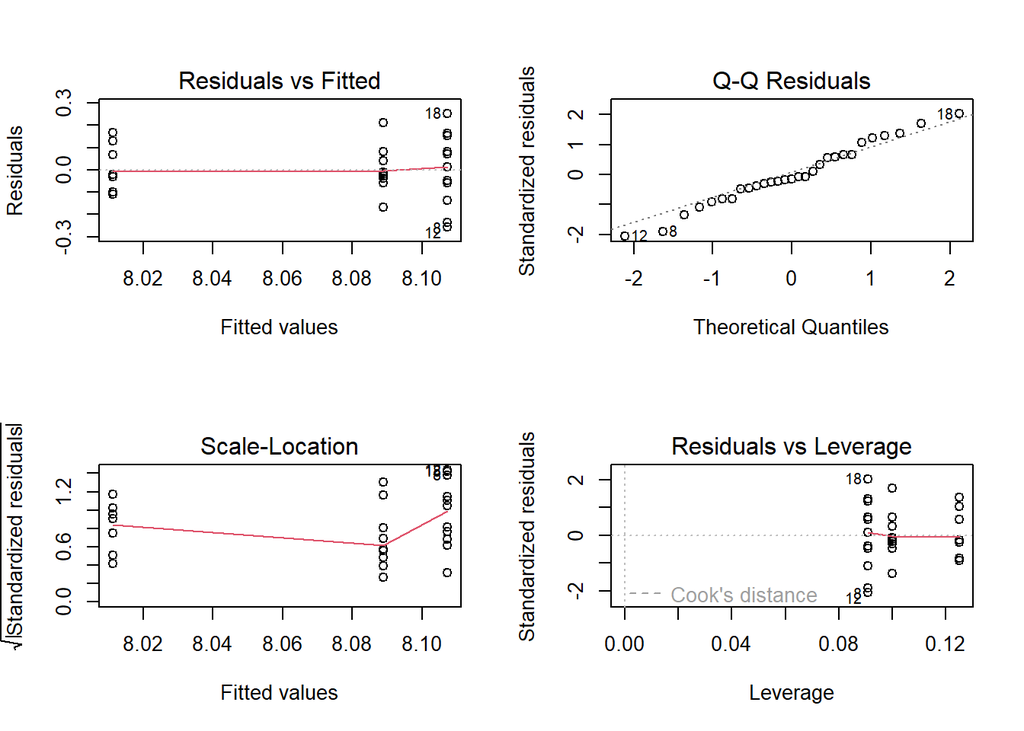

```r
#check for normalityfor pH and Treat
fit2 <- lm(pH ~ treat, data=clean_data)
par(mfrow=c(2,2))
plot(fit2)
```

```r
par(mfrow=c(1,1))


res2 <- fit2$residuals
shapiro.test(res2)
```

```
##
##  Shapiro-Wilk normality test
##
## data:  res2
## W = 0.98256, p-value = 0.8979
```

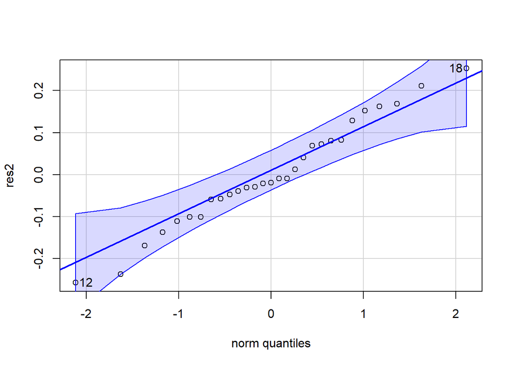

```
## [1] 12 18
```

```r
qqPlot(res2)
```